# Part I - Prosper Loan Data

## Bivariate Exploration

> In this section, investigate relationships between pairs of variables in your data. Make sure the variables that you cover here have been introduced in some fashion in the previous section (univariate exploration).

```python
numeric_attr
```

```
['Term',
 'BorrowerAPR',
 'BorrowerRate',
 'LoanOriginalAmount',
 'StatedMonthlyIncome',
 'MonthlyLoanPayment',
 'Investors']
```

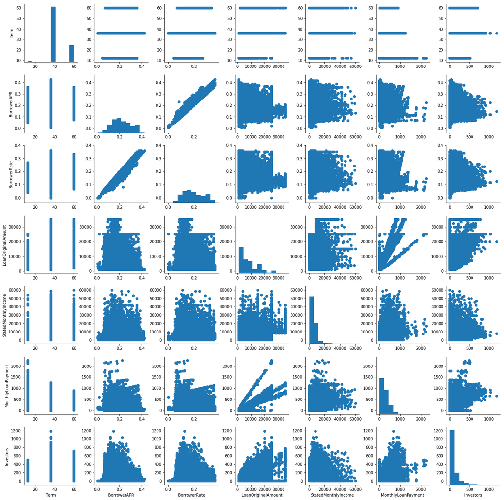

```python
df = loan_clean[loan_clean['StatedMonthlyIncome'] < 60000]
g = sb.PairGrid(data = df, vars = numeric_attr)
g.map_diag(plt.hist)
g.map_offdiag(plt.scatter)
```

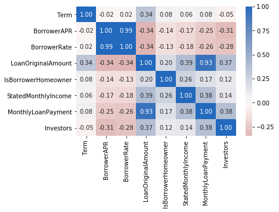

```python
sb.heatmap(df.corr(), annot = True, fmt = '.2f', cmap = 'vlag_r', center = 0)
```

> - There is **high correlation** between **BorrowerAPR** and **BorrowerRate**, also between **MonthlyLoanPaymen**t and **LoanOriginalAmount**

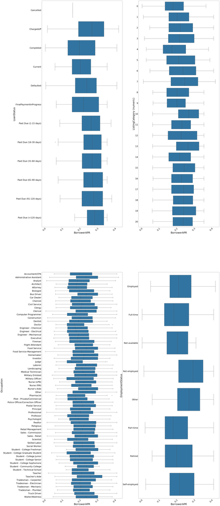

```python
plt.figure(figsize = [45,200])
grids = dynamic_subplot(len(categoric_attr))

for categ in categoric_attr:
    i = categoric_attr.index(categ)
    if i < len(categoric_attr)-1:
        plt.subplot(grids[0],grids[1], i+1)
        plot_num_vs_cat(df, categ, 'BorrowerAPR', 35, 30)
```

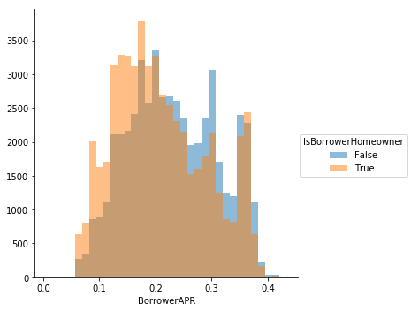

```python
span = df['BorrowerAPR'].max() - df['BorrowerAPR'].min()

bin_edges = np.arange(df['BorrowerAPR'].min(), df['BorrowerAPR'].max()+3*span/100, 3*span/100)
g = sb.FacetGrid(data = df, hue = categoric_attr[-1], size = 5)
g.map(plt.hist, "BorrowerAPR", bins = bin_edges, alpha = 0.5)
g.add_legend()
```

### Did you observe any interesting relationships between the other features (not the main feature(s) of interest)?

> - There is high correlation between MonthlyLoanPayment and LoanOriginalAmount